# Sentiment_analysis on parsed letters

Theresa Plougstrup

2025-05-14

#Parsing xml letters

```r
library(tidyverse)
library(xml2)
library(dplyr)
```

```r
letters <- tibble(file = list.files("data/Letters", pattern = "let", full.names = TRUE))
```

```r
letters <- letters %>%
  rowwise() %>%
  mutate(xml = list(read_xml(file))) %>%
  ungroup()
```

#For one file

```r
etBrev <- read_xml("data/Letters/let001.xml")
```

```r
etBrev %>%
   xml_find_all("/d1:TEI/d1:teiHeader/d1:fileDesc/d1:sourceDesc/vg:letDesc/vg:letHeading/vg:addressee") %>%
          xml_text()
```

```
## [1] "Theo van Gogh"
```

#For all 903 files

I start by opening one of the letter xml files in the program: Visual Studio Code. Here I follow the structure of one of the XML files and write down the path to e.g. the translated, english content of the letter to create a column containing that information.This way the content of all the xml files with letters - as they all have the same structure (which can be tested by seeing if all 903 letters in this case are regisered in the environment window) and the letters are thus usable in Rstudio and I can analyse them further.

For the following analysis I will be doing with these files, I decided to parsing the title of the letter, the English content, the author and the recipient of a letter and the date and place where it was sent from. It is, of course, possible to extract other information from the letters if needed.

```r
#Parsing all xml files

letters_parsed <- letters %>%
  rowwise() %>%
  mutate(title = xml %>%
           xml_find_all("/d1:TEI/d1:teiHeader/d1:fileDesc/d1:titleStmt/d1:title") %>%
           xml_text(),
         content = xml %>%
           xml_find_all('/d1:TEI/d1:text/d1:body/d1:div[@type = "translation"]') %>%
           xml_text(),
        author = xml %>%
           xml_find_all("/d1:TEI/d1:teiHeader/d1:fileDesc/d1:sourceDesc/vg:letDesc/vg:letHeading/d1:author") %>%
           xml_text(),
        recipient = xml %>%
          xml_find_all("/d1:TEI/d1:teiHeader/d1:fileDesc/d1:sourceDesc/vg:letDesc/vg:letHeading/vg:addressee") %>%
          xml_text(),
        date = xml %>%
          xml_find_all("/d1:TEI/d1:teiHeader/d1:fileDesc/d1:sourceDesc/vg:letDesc/vg:letHeading/vg:dateLet") %>%
          xml_text(),
        place = xml %>%
          xml_find_all("/d1:TEI/d1:teiHeader/d1:fileDesc/d1:sourceDesc/vg:letDesc/vg:letHeading/vg:placeLet") %>%
          xml_text())
```

```r
library("tidyverse")
library("ggwordcloud")
library("textdata")
library("tidytext")
library("lubridate")
library("here")
letters_df <- letters_parsed %>%
  mutate(text_lines = str_split(content, pattern = '\n')) %>%
  unnest(text_lines) %>%
  mutate(text_lines = str_replace_all(text_lines, "’", "'"),
         text_lines = str_trim(str_to_lower(text_lines)))
```

```r
letters_tokens <- letters_df %>%
  unnest_tokens(word, text_lines)
```

```r
stop_words <- stop_words %>%
  mutate(
    word = str_replace_all(word, "’", "'"),
    word = str_trim(str_to_lower(word))
  )
```

```r
letters_stop <- letters_tokens %>%
  anti_join(stop_words, by = "word")
```

```r
letters_no_numeric <- letters_stop %>%
  filter(is.na(as.numeric(word)))
letters_top100 <- letters_no_numeric %>%
  count(word) %>%
  arrange(desc(n)) %>%
  slice_head(n = 100)
letters_top100
```

```
## # A tibble: 100 × 2
##    word         n
##    <chr>    <int>
##  1 time      2108
##  2 letter    1372
##  3 people    1330
##  4 painting  1236
##  5 life      1116
##  6 hope      1097
##  7 dear      1066
##  8 write     1028
##  9 day        978
## 10 theo       969
## # ℹ 90 more rows
```

```r
view(letters_top100)
```

```r
#Filter letters from June 1889 where Starry Night was painted

letters_df <- letters_df %>%
  mutate(
    date_first = str_extract(date, "\\b\\w+,\\s*\\d{1,2}\\s+\\w+\\s+\\d{4}\\b"),
    date_parsed = dmy(str_remove(date_first, "^\\w+,\\s*"))
  )
```

```r
letters_june_1889 <- letters_df %>%
  filter(!is.na(date_parsed),
         year(date_parsed) == 1889,
         month(date_parsed) == 6)
```

```r
get_sentiments(lexicon = "afinn")
```

```
## # A tibble: 2,477 × 2
##    word       value
##    <chr>      <dbl>
##  1 abandon       -2
##  2 abandoned     -2
##  3 abandons      -2
##  4 abducted      -2
##  5 abduction     -2
##  6 abductions    -2
##  7 abhor         -3
##  8 abhorred      -3
##  9 abhorrent     -3
## 10 abhors        -3
## # ℹ 2,467 more rows
```

```r
get_sentiments(lexicon = "nrc")
```

```
## # A tibble: 13,872 × 2
##    word        sentiment
##    <chr>       <chr>
##  1 abacus      trust
##  2 abandon     fear
##  3 abandon     negative
##  4 abandon     sadness
##  5 abandoned   anger
##  6 abandoned   fear
##  7 abandoned   negative
##  8 abandoned   sadness
##  9 abandonment anger
## 10 abandonment fear
## # ℹ 13,862 more rows
```

```r
june_tokens <- letters_june_1889 %>%
  unnest_tokens(word, text_lines)
```

```r
letters_1889_afinn <- june_tokens %>%
  inner_join(get_sentiments("afinn"), by = "word")

letters_1889_afinn
```

```
## # A tibble: 326 × 12
##    file         xml        title content author recipient date  place date_first
##    <chr>        <list>     <chr> <chr>   <chr>  <chr>     <chr> <chr> <chr>
##  1 data/Letter… <xml_dcmn> To T… "My de… Vince… Theo van… betw… Sain… Thursday,…
##  2 data/Letter… <xml_dcmn> To T… "My de… Vince… Theo van… betw… Sain… Thursday,…
##  3 data/Letter… <xml_dcmn> To T… "My de… Vince… Theo van… betw… Sain… Thursday,…
##  4 data/Letter… <xml_dcmn> To T… "My de… Vince… Theo van… betw… Sain… Thursday,…
##  5 data/Letter… <xml_dcmn> To T… "My de… Vince… Theo van… betw… Sain… Thursday,…
##  6 data/Letter… <xml_dcmn> To T… "My de… Vince… Theo van… betw… Sain… Thursday,…
##  7 data/Letter… <xml_dcmn> To T… "My de… Vince… Theo van… betw… Sain… Thursday,…
##  8 data/Letter… <xml_dcmn> To T… "My de… Vince… Theo van… betw… Sain… Thursday,…
##  9 data/Letter… <xml_dcmn> To T… "My de… Vince… Theo van… betw… Sain… Thursday,…
## 10 data/Letter… <xml_dcmn> To T… "My de… Vince… Theo van… betw… Sain… Thursday,…
## # ℹ 316 more rows
## # ℹ 3 more variables: date_parsed <date>, word <chr>, value <dbl>
```

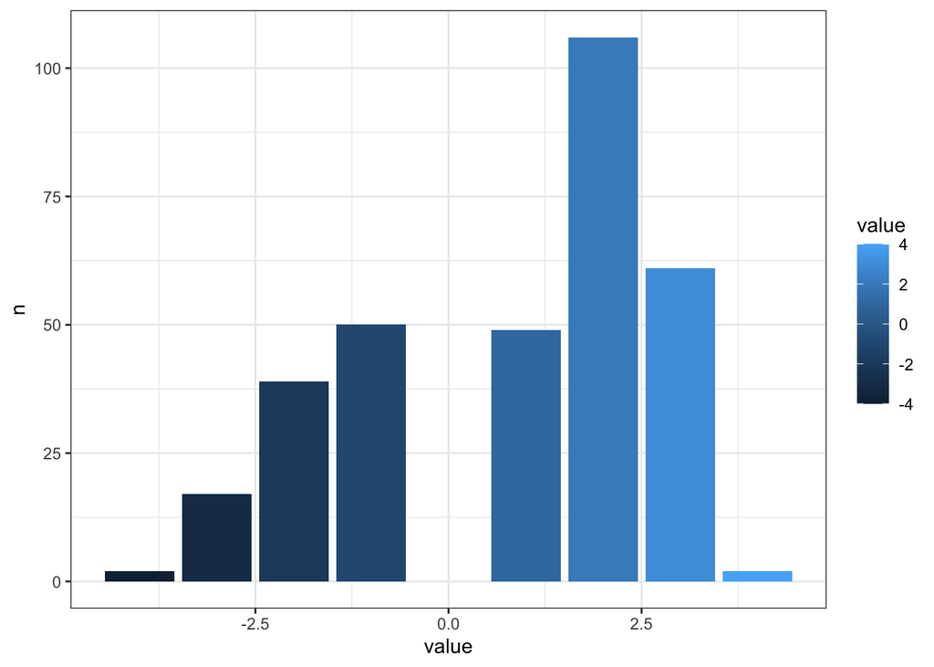

```r
letters_afinn_hist <- letters_1889_afinn %>%
  count(value)

ggplot(data = letters_afinn_hist, aes(x = value, y = n)) +
  geom_col(aes(fill = value)) +
  theme_bw()
```

```r
letters_1889_afinn %>%
  summarise(
    mean_score = mean(value),
    median_score = median(value))
```

```
## # A tibble: 1 × 2
##   mean_score median_score
##        <dbl>        <dbl>
## 1      0.813            2
```

```r
letters_1889_afinn2 <- letters_1889_afinn %>%
  filter(value == 2)

letters_1889_afinn2
```

```
## # A tibble: 106 × 12
##    file         xml        title content author recipient date  place date_first
##    <chr>        <list>     <chr> <chr>   <chr>  <chr>     <chr> <chr> <chr>
##  1 data/Letter… <xml_dcmn> To T… "My de… Vince… Theo van… betw… Sain… Thursday,…
##  2 data/Letter… <xml_dcmn> To T… "My de… Vince… Theo van… betw… Sain… Thursday,…
##  3 data/Letter… <xml_dcmn> To T… "My de… Vince… Theo van… betw… Sain… Thursday,…
##  4 data/Letter… <xml_dcmn> To T… "My de… Vince… Theo van… betw… Sain… Thursday,…
##  5 data/Letter… <xml_dcmn> To T… "My de… Vince… Theo van… betw… Sain… Thursday,…
##  6 data/Letter… <xml_dcmn> To T… "My de… Vince… Theo van… betw… Sain… Thursday,…
##  7 data/Letter… <xml_dcmn> To T… "My de… Vince… Theo van… betw… Sain… Thursday,…
##  8 data/Letter… <xml_dcmn> To T… "My de… Vince… Theo van… betw… Sain… Thursday,…
##  9 data/Letter… <xml_dcmn> To T… "My de… Vince… Theo van… betw… Sain… Thursday,…
## 10 data/Letter… <xml_dcmn> To T… "My de… Vince… Theo van… betw… Sain… Thursday,…
## # ℹ 96 more rows
## # ℹ 3 more variables: date_parsed <date>, word <chr>, value <dbl>
```

```r
letters_1889_nrc <- june_tokens %>%
  inner_join(get_sentiments("nrc"), by = "word")
letters_1889_nrc
```

```
## # A tibble: 1,149 × 12
##    file         xml        title content author recipient date  place date_first
##    <chr>        <list>     <chr> <chr>   <chr>  <chr>     <chr> <chr> <chr>
##  1 data/Letter… <xml_dcmn> To T… "My de… Vince… Theo van… betw… Sain… Thursday,…
##  2 data/Letter… <xml_dcmn> To T… "My de… Vince… Theo van… betw… Sain… Thursday,…
##  3 data/Letter… <xml_dcmn> To T… "My de… Vince… Theo van… betw… Sain… Thursday,…
##  4 data/Letter… <xml_dcmn> To T… "My de… Vince… Theo van… betw… Sain… Thursday,…
##  5 data/Letter… <xml_dcmn> To T… "My de… Vince… Theo van… betw… Sain… Thursday,…
##  6 data/Letter… <xml_dcmn> To T… "My de… Vince… Theo van… betw… Sain… Thursday,…
##  7 data/Letter… <xml_dcmn> To T… "My de… Vince… Theo van… betw… Sain… Thursday,…
##  8 data/Letter… <xml_dcmn> To T… "My de… Vince… Theo van… betw… Sain… Thursday,…
##  9 data/Letter… <xml_dcmn> To T… "My de… Vince… Theo van… betw… Sain… Thursday,…
## 10 data/Letter… <xml_dcmn> To T… "My de… Vince… Theo van… betw… Sain… Thursday,…
## # ℹ 1,139 more rows
## # ℹ 3 more variables: date_parsed <date>, word <chr>, sentiment <chr>
```

```r
letters_exclude <- june_tokens %>%
  anti_join(get_sentiments("nrc"))
letters_exclude
```

```
## # A tibble: 5,663 × 11
##    file         xml        title content author recipient date  place date_first
##    <chr>        <list>     <chr> <chr>   <chr>  <chr>     <chr> <chr> <chr>
##  1 data/Letter… <xml_dcmn> To T… "My de… Vince… Theo van… betw… Sain… Thursday,…
##  2 data/Letter… <xml_dcmn> To T… "My de… Vince… Theo van… betw… Sain… Thursday,…
##  3 data/Letter… <xml_dcmn> To T… "My de… Vince… Theo van… betw… Sain… Thursday,…
##  4 data/Letter… <xml_dcmn> To T… "My de… Vince… Theo van… betw… Sain… Thursday,…
##  5 data/Letter… <xml_dcmn> To T… "My de… Vince… Theo van… betw… Sain… Thursday,…
##  6 data/Letter… <xml_dcmn> To T… "My de… Vince… Theo van… betw… Sain… Thursday,…
##  7 data/Letter… <xml_dcmn> To T… "My de… Vince… Theo van… betw… Sain… Thursday,…
##  8 data/Letter… <xml_dcmn> To T… "My de… Vince… Theo van… betw… Sain… Thursday,…
##  9 data/Letter… <xml_dcmn> To T… "My de… Vince… Theo van… betw… Sain… Thursday,…
## 10 data/Letter… <xml_dcmn> To T… "My de… Vince… Theo van… betw… Sain… Thursday,…
## # ℹ 5,653 more rows
## # ℹ 2 more variables: date_parsed <date>, word <chr>
```

```r
letters_exclude_n <- letters_exclude %>%
  count(word, sort = TRUE)

head(letters_exclude_n)
```

```
## # A tibble: 6 × 2
##   word      n
##   <chr> <int>
## 1 the     307
## 2 to      189
## 3 and     177
## 4 of      167
## 5 a       157
## 6 that    148
```

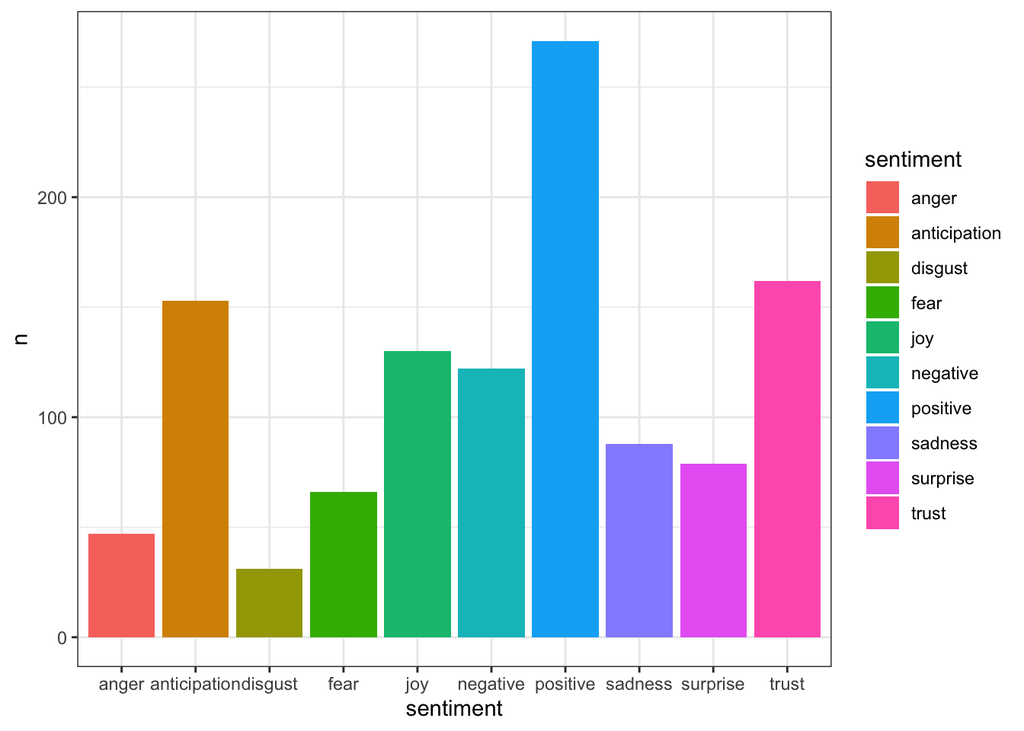

```r
letters_1889_nrc_n <- letters_1889_nrc %>%
  count(sentiment, sort = TRUE)

ggplot(data = letters_1889_nrc_n, aes(x = sentiment, y = n)) +
  geom_col(aes(fill = sentiment))+
  theme_bw()
```

```r
letters_1889_nrc_n5 <- letters_1889_nrc %>%
  count(word,sentiment, sort = TRUE) %>%
  group_by(sentiment) %>%
  top_n(7) %>%
  ungroup()
```

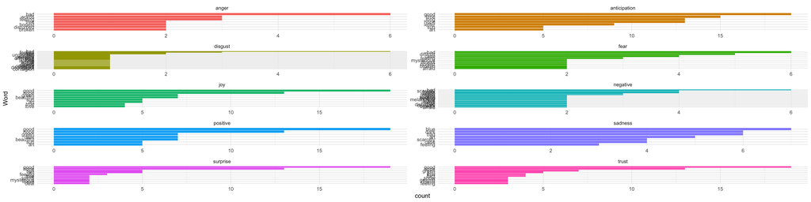

```r
letters_1889_nrc_gg <- ggplot(data = letters_1889_nrc_n5, aes(x = reorder(word,n), y = n, fill = sentiment)) +
  geom_col(show.legend = FALSE) +
  facet_wrap(~sentiment, ncol = 2, scales = "free") +
  coord_flip() +
  theme_minimal() +
  labs(x = "Word", y = "count")

letters_1889_nrc_gg
```

```r
ggsave(plot = letters_1889_nrc_gg,
       here("figures","letters_1889_nrc_sentiment.png"),
       height = 10,
       width = 7)
```